# nltk尝试

```python
%matplotlib inline
```

```python
import nltk
```

```python
from nltk.book import *
```

```
*** Introductory Examples for the NLTK Book ***
Loading text1, ..., text9 and sent1, ..., sent9
Type the name of the text or sentence to view it.
Type: 'texts()' or 'sents()' to list the materials.
text1: Moby Dick by Herman Melville 1851
text2: Sense and Sensibility by Jane Austen 1811
text3: The Book of Genesis
text4: Inaugural Address Corpus
text5: Chat Corpus
text6: Monty Python and the Holy Grail
text7: Wall Street Journal
text8: Personals Corpus
text9: The Man Who Was Thursday by G . K . Chesterton 1908
```

### 题目一、

制作text2（《理智与情感》）中四个主角：Elinor，Marianne，Edward 和Willoughby 的分布图。在这部小说中关于男性和女性所扮演的不同角色，你能观察到什么？能找出一对夫妻吗？

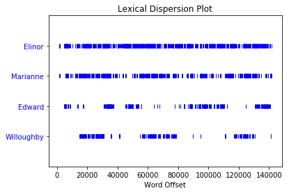

```python
text2.dispersion_plot(["Elinor", "Marianne", "Edward", "Willoughby"])
```

### 题目二、

在聊天语料库（text5）中查找所有以字母v开头的词，按字母顺序显示出来。找出text5中所有3个字母的词。使用频率分布函数（FreqDist），以频率从高到低显示这些词。

1.查找所有以字母v开头的词，按字母顺序显示出来

```python
sorted(w for w in set(text5) if w.startswith('v'))
```

```
['va',
 'valiant',
 'vamp',
 'van',
 'vanished',
 'veg',
 'vega',
 'vent',
 'very',
 'vetrabrate',
 'vicious',
 'victims',
 'victors',
 'video',
 'vigilant',
 'village',
 'vindictive',
 'vinyl',
 'violators',
 'virgin',
 'virginal',
 'virginity',
 'virgo',
 'visual',
 'vm',
 'vodka',
 'voice',
 'voices',
 'vomiting',
 'vote',
 'voter',
 'vs.',
 'vuela']
```

2.找出text5中所有3个字母的词。使用频率分布函数（FreqDist），以频率从高到低显示这些词

（注意这里不能用set(text5)，否则所有词出现的频数会变成1，有的同学这里做错了）（有没有.isalpha()都可以）

```python
FreqDist([w for w in text5 if len(w) == 3 and w.isalpha()]).most_common()
```

```
[('lol', 704),
 ('the', 646),
 ('you', 635),
 ('and', 335),
 ('hey', 264),
 ('for', 188),
 ('are', 178),
 ('not', 170),
 ('all', 165),
 ('was', 142),
 ('how', 128),
 ('too', 125),
 ('any', 123),
 ('out', 107),
 ('can', 105),
 ('get', 102),
 ('who', 99),
 ('did', 92),
 ('but', 90),
 ('one', 87),
 ('LOL', 87),
 ('now', 79),
 ('see', 75),
 ('her', 71),
 ('yes', 69),
 ('got', 68),
 ('its', 66),
 ('why', 59),
 ('had', 50),
 ('she', 47),
 ('off', 47),
 ('bye', 44),
 ('has', 42),
 ('You', 42),
 ('him', 41),
 ('his', 38),
 ('hot', 37),
 ('say', 34),
 ('man', 33),
 ('brb', 33),
```

[output cut: 480 more lines]

```
 ('RUN', 1),
 ('CUZ', 1),
 ('MAN', 1),
 ('bes', 1),
 ('hav', 1),
 ('yap', 1),
 ('lag', 1),
 ('Her', 1),
 ('THE', 1),
 ('msg', 1),
 ('MSN', 1),
 ('Meh', 1),
 ('USA', 1),
 ('ovr', 1),
 ('fot', 1)]
```

### 题目三：

对以下要求，找出text2 中所有符合下列条件的词，每种要求写一个表达式。结果是词链表的形式：['word 1', 'word2', ...]。 以or 结尾；b. 包含字母k；c. 包含字母序列wh；d. 除了首字母外是全部小写字母的词（即titlecase）。

a. 以or 结尾

（排不排序没所谓；有没有.isalpha()都可以；不过最好set(text2)一下）

```python
sorted(w for w in set(text2) if w.endswith('or') and w.isalpha())
```

```
['Doctor',
 'Elinor',
 'For',
 'Nor',
 'Poor',
 'Taylor',
 'abhor',
 'author',
 'bachelor',
 'counsellor',
 'demeanor',
 'door',
 'endeavor',
 'error',
 'exterior',
 'floor',
 'for',
 'honor',
 'horror',
 'inferior',
 'inheritor',
 'labor',
 'liquor',
 'manor',
 'metaphor',
 'minor',
 'narrator',
 'nor',
 'or',
 'orator',
 'poor',
 'possessor',
 'prior',
 'proprietor',
 'stupor',
 'suitor',
 'superior',
 'terror',
 'vigor',
 'visitor']
```

b. 包含字母k

```python
sorted(w for w in set(text2) if 'k' in w and w.isalpha())
```

```
['Berkeley',
 'Clarke',
 'Like',
 'Look',
 'Luckily',
 'Norfolk',
 'Park',
 'Sackville',
 'Shakespeare',
 'Sparks',
 'Take',
 'Thank',
 'Think',
 'Walker',
 'Whitakers',
 'acknowledge',
 'acknowledged',
 'acknowledging',
 'acknowledgment',
 'acknowledgments',
 'alike',
 'ankle',
 'ankles',
 'ask',
 'asked',
 'asking',
 'attack',
 'attacked',
 'attacks',
 'awake',
 'awaken',
 'awakened',
 'awakening',
 'awaking',
 'awkward',
 'awkwardness',
 'awoke',
 'back',
 'backwardness',
 'backwards',
```

[output cut: 235 more lines]

```
 'weaken',
 'weakened',
 'weakening',
 'weakness',
 'weaknesses',
 'week',
 'weeks',
 'wicked',
 'wicket',
 'winks',
 'work',
 'worked',
 'working',
 'workmen',
 'works']
```

c. 包含字母序列wh

```python
sorted(w for w in set(text2) if 'wh' in w and w.isalpha())
```

```
['awhile',
 'elsewhere',
 'meanwhile',
 'somewhat',
 'somewhere',
 'what',
 'whatever',
 'when',
 'whence',
 'whenever',
 'where',
 'wherever',
 'whether',
 'which',
 'while',
 'whiled',
 'whims',
 'whip',
 'whisper',
 'whispered',
 'whispering',
 'whist',
 'white',
 'whiter',
 'whither',
 'who',
 'whoever',
 'whole',
 'wholly',
 'whom',
 'whomsoever',
 'whose',
 'why']
```

d. 除了首字母外是全部小写字母的词（即titlecase）

```python
sorted(w for w in set(text2) if w.istitle() and w.isalpha())
```

```
['A',
 'Abbeyland',
 'About',
 'Absence',
 'Abundance',
 'Add',
 'Affecting',
 'After',
 'Again',
 'Against',
 'Ah',
 'All',
 'Allenham',
 'Allow',
 'Almost',
 'Altogether',
 'Am',
 'Among',
 'Amongst',
 'An',
 'And',
 'Annamaria',
 'Anne',
 'Another',
 'Anxiety',
 'April',
 'Are',
 'As',
 'Ashamed',
 'Astonished',
 'Astonishment',
 'At',
 'Austen',
 'Avignon',
 'Ay',
 'Aye',
 'Bad',
 'Bartlett',
 'Barton',
 'Bath',
```

[output cut: 474 more lines]

```
 'Will',
 'William',
 'Williams',
 'Willing',
 'Willoughby',
 'Willoughbys',
 'With',
 'Within',
 'Without',
 'Would',
 'Writing',
 'Yes',
 'Yet',
 'You',
 'Your']
```